[O’Hara on GitHub](https://github.com/oharac)

# Set up IUCN marine species list and risk assessments

Compiled on Sat Aug 4 19:03:37 2018 by ohara

```r
knitr::opts_chunk$set(fig.width = 6, fig.height = 4, fig.path = 'Figs/',
                      echo = TRUE, message = FALSE, warning = FALSE)


source('https://raw.githubusercontent.com/oharac/src/master/R/common.R')

dir_git <- '~/github/spp_risk_dists'

### provenance tracking
library(provRmd); prov_setup()

### goal specific folders and info
dir_setup   <- file.path(dir_git, 'data_setup')
dir_o_anx <- file.path(dir_O, 'git-annex/spp_risk_dists')

source(file.path(dir_setup, 'common_fxns.R'))
```

# 1 Summary

Get IUCN current risk assessments and historical assessments over time, for all IUCN marine species. This method is not reliant on any information from AquaMaps.

# 2 Data Sources

### 2.0.1 IUCN Red List

# 3 Methods

## 3.1 Get IUCN historical assessments for all available IUCN marine spp

### 3.1.1 Get info on all species

Using the `mc_get_from_api()` function, get the entire species list of IUCN Red List assessed species. This includes terrestrial and marine.

```r
### Get all pages and bind into total species list.  This is pretty fast.

spp_info_from_api_file <- file.path(dir_o_anx, sprintf('iucn/spp_info_from_api_%s.csv', api_version))
reload <- FALSE

if(!file.exists(spp_info_from_api_file) | reload) {

  cat_msg('Using API to create full species list from scratch')

  spp_npage_url <- sprintf('http://apiv3.iucnredlist.org/api/v3/speciescount?token=%s', api_key)
  n_spp <- fromJSON(spp_npage_url) %>%
    .$count %>% as.integer()
  n_pages <- ceiling(n_spp/10000)

  spp_page_url <- 'http://apiv3.iucnredlist.org/api/v3/species/page/%s?token=%s'
  spp_df_all <- mc_get_from_api(spp_page_url, c(0:(n_pages - 1)), api_key, delay = 1)

  spp_df_all <- spp_df_all %>%
    dplyr::select(-infra_rank, -infra_name, -count, -page) %>%
    rename(iucn_sid = taxonid, sciname = scientific_name) %>%
    setNames(names(.) %>%
               str_replace('_name', ''))

  cat_msg('Full list length: ', nrow(spp_df_all), '; unique species IDs: ',
          length(spp_df_all$iucn_sid %>% unique()))
  write_csv(spp_df_all, spp_info_from_api_file)

} else {

  cat_msg('File of API species list exists: \n  ', spp_info_from_api_file)
  git_prov(spp_info_from_api_file, filetype = 'output')

}
```

### 3.1.2 Determine marine species using habitat information

#### 3.1.2.1 Get species habitat info for all species from IUCN API

From the full IUCN species list, send each IUCN species ID into the API to get the habitats listed for that species. Combine all habitat dataframes into a master dataframe of all habitats for all species. Note that many species do not have habitat information and will be listed as NA for habitat variables.

```r
### For each species ID on the total list, get a dataframe of habitats.
### This is slow.  Skip if possible.

spp_habs_from_api_file <- file.path(dir_o_anx, sprintf('iucn/spp_habs_from_api_%s.csv', api_version))
reload <- FALSE

if(!file.exists(spp_habs_from_api_file) | reload) {

  cat_msg('Using API to determine species habitats from full species info list')

  spp_ids_all <- read_csv(spp_info_from_api_file) %>%
    .$iucn_sid

  spp_habs_url <- 'http://apiv3.iucnredlist.org/api/v3/habitats/species/id/%s?token=%s'


  ### Breaking this into chunks...
  ### 500 spp takes 184 seconds; at that rate, 87851 species should take
  ###   about 9 hrs.  Each chunk will save to tmp for later combining.

  chunk_size <- 2000
  n_chunks <- ceiling(length(spp_ids_all)/chunk_size)

  if(!dir.exists(file.path(dir_o_anx, 'tmp'))) {
    dir.create(file.path(dir_o_anx, 'tmp'))
  }

  for(j in 1:n_chunks) {
    ### j <- 2
    spp_index <- c( ((j - 1) * chunk_size + 1) : min((j * chunk_size), length(spp_ids_all)) )
    chunk_file <- file.path(dir_o_anx, 'tmp',
                    sprintf('spp_habs_chunk_%s_%s.csv',
                            min(spp_index), max(spp_index)))

    if(!file.exists(chunk_file)) {
      cat_msg('Getting habitat info for species ', min(spp_index), ' to ', max(spp_index))

      spp_ids_chunk <- spp_ids_all[spp_index]
      spp_habs_chunk <- mc_get_from_api(spp_habs_url, spp_ids_chunk, api_key, cores = 12, delay = .5)
      cat_msg('... found ', nrow(spp_habs_chunk), ' habitat rows for these species')

      write_csv(spp_habs_chunk, chunk_file)

    } else {

      cat_msg('Chunk file ', chunk_file, ' already exists; skipping these spp')

    }
  }

  ### fields:
  ### id | code | habitat | suitability | season | majorimportance

  spp_hab_chunk_files <- list.files(file.path(dir_o_anx, 'tmp'),
                                    pattern = 'spp_habs_chunk',
                                    full.names = TRUE)

  spp_habs_df <- lapply(spp_hab_chunk_files, FUN = function(x) {
    read.csv(x) %>%
      mutate(code = as.character(code))}) %>%
    bind_rows() %>%
    rename(iucn_sid = id) %>%
    mutate(iucn_sid = ifelse(is.na(iucn_sid), param_id, iucn_sid)) %>%
    arrange(iucn_sid)

  spp_errors <- spp_habs_df %>%
    filter(!is.na(api_error) & api_error != 'no data.frame') %>%
    .$iucn_sid
  ### all these errors are due to returning a zero-length list instead of a data.frame

  write_csv(spp_habs_df, spp_habs_from_api_file)

} else {

  cat_msg('File of species habitats from API exists: \n  ', spp_habs_from_api_file)
  git_prov(spp_habs_from_api_file, filetype = 'output')

}
```

```r
### For each species ID on the total list, get species information, which
### includes "system" of marine, terrestrial, or both.

spp_sys_from_api_file <- file.path(dir_o_anx, sprintf('iucn/spp_systems_from_api_%s.csv', api_version))
reload <- FALSE

if(!file.exists(spp_sys_from_api_file) | reload) {

  cat_msg('Using API to determine species systems from full species info list')

  spp_ids_all <- read_csv(spp_info_from_api_file) %>%
    .$iucn_sid

  spp_systems_url <- 'http://apiv3.iucnredlist.org/api/v3/species/id/%s?token=%s'

  ### Breaking this into chunks...
  ### 500 spp takes 184 seconds; at that rate, 87851 species should take
  ###   about 9 hrs.  Each chunk will save to tmp for later combining.

  chunk_size <- 2000
  n_chunks <- ceiling(length(spp_ids_all)/chunk_size)

  if(!dir.exists(file.path(dir_o_anx, 'tmp'))) {
    dir.create(file.path(dir_o_anx, 'tmp'))
  }

  for(j in 1:n_chunks) {
    ### j <- 1
    spp_index <- c( ((j - 1) * chunk_size + 1) : min((j * chunk_size), length(spp_ids_all)) )
    chunk_file <- file.path(dir_o_anx, 'tmp',
                    sprintf('spp_sys_chunk_%s_%s.csv',
                            min(spp_index), max(spp_index)))

    if(!file.exists(chunk_file) | reload) {
      cat_msg('Getting systems info for species ', min(spp_index), ' to ', max(spp_index))

      spp_ids_chunk <- spp_ids_all[spp_index]
      spp_sys_chunk <- mc_get_from_api(spp_systems_url, spp_ids_chunk, api_key,
                                       cores = 12, delay = .5)

      spp_sys_chunk <- spp_sys_chunk %>%
        select(iucn_sid = name,
               sciname = scientific_name, comname = main_common_name,
               contains('system'), year = published_year, category, criteria)
      cat_msg('... found ', nrow(spp_sys_chunk), ' systems for these species')

      write_csv(spp_sys_chunk, chunk_file)

    } else {

      cat_msg('Chunk file ', chunk_file, ' already exists; skipping these spp')

    }
  }

  ### fields:
  ### id | code | habitat | suitability | season | majorimportance

  spp_sys_chunk_files <- list.files(file.path(dir_o_anx, 'tmp'),
                                    pattern = 'spp_sys_chunk',
                                    full.names = TRUE)

  spp_sys_df <- lapply(spp_sys_chunk_files, FUN = function(x) {
      read.csv(x)
    }) %>%
    bind_rows() %>%
    arrange(iucn_sid)

  write_csv(spp_sys_df, spp_sys_from_api_file)

} else {

  cat_msg('File of species habitats from API exists: \n  ', spp_sys_from_api_file)
  git_prov(spp_sys_from_api_file, filetype = 'output')

}
```

#### 3.1.2.2 Generate Habitat inclusion list

```r
hab_inclusion_file <- file.path(dir_setup, 'int', 'iucn_habitat_categories.csv')

hab_cats <- read_csv(spp_habs_from_api_file, col_types = 'iciccccc') %>%
  select(habitat, code) %>%
  distinct() %>%
  separate(code, c('cat', 'subcat1', 'subcat2'),
           remove = FALSE, convert = TRUE) %>%
  arrange(cat, subcat1, subcat2) %>%
  mutate(include = ifelse(cat %in% c(9:12), TRUE, FALSE),
         include = ifelse(cat == 15 & subcat1 %in% c(11, 12, 13), TRUE, include),
         include = ifelse(cat == 13 & subcat1 == 1, TRUE, include),
           ### Category 13 (Marine coastal/supratidal excluded here: except for
           ### sea cliffs and offshore islands (13.1))
         include = ifelse(cat %in% 17:18, TRUE, include)) %>%
           ### 17 and 18 are "other" and "unknown"; "unknown" includes some
           ### marine spp e.g. 170022 and 170033, slipper lobsters; "other"
           ### also includes marine spp e.g. 60087 sepia stingray
  filter(!is.na(code))

### Note these "include" values were manually determined by inspecting the habitat categories
### Notes on categories related to depth clipping
### see also: http://www.iucnredlist.org/technical-documents/classification-schemes/habitats-classification-scheme-ver3
### * category 9 is neritic (shallow) though 9.1 is specifically pelagic (NOT shallow)
### * category 10 is oceanic at different depths (pelagic: NOT shallow)
### * category 11 is Marine Deep Ocean Floor (Benthic and Demersal) (NOT shallow)
### * category 12 is Marine Intertidal (shallow)
### * category 13 is Marine Coastal/Supratidal (shallow)
### * category 15 includes shallow structures
### So: for depth clipping, cut at 200 m for all but category 9.1, 10, 11

write_csv(hab_cats, hab_inclusion_file)
```

#### 3.1.2.3 Determine marine species and depth constraints

Marine species depth classifications:

- 0-20? m: organisms classified as intertidal (category 12) and shallower
- 0-200 m: organisms classified as neritic (category 9) and shallower
- no limit: organisms in marine oceanic (category 10) and deep benthic (category 11)

It appears that coastal species suffer from the extended buffers so clipping these to a 200 m bathymetry line is important. Intertidal organisms may benefit from further clipping to shallower depths, depending on the quality of bathymetric layers.

```r
spp_habs_from_api <- read_csv(spp_habs_from_api_file,
                              col_types = '__iccccc')
### 'code' is character since it is in the form x.xx.xxx

spp_systems_from_api <- read_csv(spp_sys_from_api_file) %>%
  select(iucn_sid, sciname, comname, marine_system, terrestrial_system, freshwater_system) %>%
  distinct()

hab_marine <- read_csv(hab_inclusion_file)

### using inner_join, use marine hab lookup to attach to the full spp habitat
### list, adding more info and filtering to just marine habitats or marine systems
spp_habs_and_systems <- spp_habs_from_api %>%
  left_join(spp_systems_from_api, by = 'iucn_sid') %>%
  left_join(hab_marine, by = c('habitat', 'code'))

### Spot checks:  how to best differentiate true marine spp?
# qwer <- spp_habs_and_systems %>%
#   filter(include == TRUE)
# length(qwer$iucn_sid %>% unique())
# length(qwer %>% filter(!cat %in% 17:18) %>% .$iucn_sid %>% unique())
### 15105 spp marine by habitat only (NAs dropped); note undoubtedly
### some "other" and "unknown" that are NOT marine - only 12108 when
### excluding "other" and "unknown"

# asdf <- spp_habs_and_systems %>%
#   filter(marine_system) %>%
#   distinct()
# length(asdf$iucn_sid %>% unique())
### 13188 spp by marine_system only; some might be marine/terrestrial

# zxcv <- spp_habs_and_systems %>%
#   filter(include == TRUE | (is.na(include) & marine_system == TRUE)) %>%
#   distinct()
# length(zxcv$iucn_sid %>% unique())
# length(zxcv %>% filter(!cat %in% 17:18) %>% .$iucn_sid %>% unique())
### 16253 in marine habitats, and/or with NA habitat but marine_system
### 13256 when ignoring "other" and "unknown"

# qwer <- spp_habs_and_systems %>%
#   filter((include == TRUE | is.na(include)) & marine_system == TRUE)
# length(qwer$iucn_sid %>% unique())
### 12934 both marine hab (or NA hab) AND marine_system

### Let's examine the spp that are marine_system but not by hab,
### and by hab but not marine_system.
# asdf <- spp_habs_and_systems %>%
#   filter(include == TRUE & !marine_system)
# length(asdf$iucn_sid %>% unique())
# length(asdf %>% filter(!cat %in% 17:18) %>% .$iucn_sid %>% unique())
### 3319 spp: including "other" and "unknown" requires an additional filter... just
### too many extras included here.  782 if we ignore those.
# zxcv <- spp_habs_and_systems %>%
#   group_by(iucn_sid) %>%
#   mutate(include = any(include == TRUE)) %>%
#   filter(include == FALSE & marine_system)
# length(zxcv$iucn_sid %>% unique())
### 254 spp here.  This looks pretty solid - the remainders look like
### they are inland wetlands, coastal lakes, caves, etc.  Some may
### be misclassified by IUCN as to their habitats.

spp_marine <- spp_habs_and_systems %>%
  filter((include == TRUE | is.na(include)) & marine_system == TRUE)
# length(spp_marine$iucn_sid %>% unique())
### These 12934 spp either are positively coded hab or NA hab, and
### ALSO classified as marine system.  This is a reasonably aggressive
### cut that seems to minimize false positives and false negatives.
### NOTE: This still includes hippos because of estuaries - see next cut.

### See which species are only "marginal" or of unknown suitability for
### marine habitats.  Filter out those that are pelagic, subtidal -
### those are clearly marine species.  If spp are only found in
### intertidal as a marginal habitat, inspect them - perhaps they're
### terrestrial that venture into intertidal occasionally... should they be included?
marg_suit <- spp_marine %>%
  group_by(iucn_sid) %>%
  filter(include == TRUE) %>%
  arrange(suitability) %>%
  summarize(suit_all = tolower(paste0(unique(suitability), collapse = ', ')),
            intertidal_only = sum(!cat %in% c(12) & !(cat == 9 & subcat1 == 10)) == 0) %>%
              ### cat 9.10 is estuaries - if only intertidal or estuaries, check for suitability
  filter(!str_detect(suit_all, 'suitable|unknown|^na')) %>%
  filter(intertidal_only) %>%
  left_join(read_csv(spp_info_from_api_file), by = 'iucn_sid') %>%
  select(iucn_sid, sciname, suit_all, kingdom, phylum, class, order, family)

### 21 spp
write_csv(marg_suit, file.path(dir_setup, 'int',
                               sprintf('spp_marine_marginal_%s.csv', api_version)))

### Trim down to just the species ID, a quick list of habitats, and whether
### the species should be considered to be OK for deeper waters (200 m +)
spp_habs_clean <- spp_marine %>%
  filter(!iucn_sid %in% marg_suit$iucn_sid) %>%
  group_by(iucn_sid) %>%
  summarize(habs = paste0(code, collapse = ', '),
            max_depth = case_when(any(cat %in% c(10, 11)) ~ '200 m +',
                                  any(cat %in% c(9, 15))  ~ '< 200 m',
                                  any(cat %in% c(12))     ~ '< 20 m',
                                  TRUE                    ~ 'unknown'))

write_csv(spp_habs_clean, file.path(dir_git, 'data',
                                     sprintf('spp_marine_from_api_%s.csv', api_version)))
```

```r
spp_timeseries_file <- file.path(dir_git, 'data',
                                 sprintf('iucn_risk_timeseries_%s.csv', api_version))

iucn_spp_info <- read_csv(file.path(dir_o_anx,
                                    sprintf('iucn/spp_info_from_api_%s.csv', api_version)))

iucn_marine_spp <- read_csv(file.path(dir_git, 'data',
                                      sprintf('spp_marine_from_api_%s.csv', api_version))) %>%
  left_join(iucn_spp_info)
### Subpopulations are in here too, by ID number

reload <- FALSE

if(!file.exists(spp_timeseries_file) | reload) {

  spp_hist_url <- 'http://apiv3.iucnredlist.org/api/v3/species/history/id/%s?token=%s'

  sid_list <- iucn_marine_spp %>%
    .$iucn_sid %>%
    unique() %>%
    sort()

  ptm <- proc.time()
  spp_past_df <- mc_get_from_api(spp_hist_url, sid_list, api_key, delay = 1, cores = 16)
  cat_msg('elapsed time: ', (proc.time() - ptm)[3])


  ### Clean up the time series: reclassify old codes to current
  cat_lookup <- read_csv(file.path(dir_setup, 'raw', 'risk_code_lookup.csv'))

  spp_past_df1 <- spp_past_df %>%
    left_join(cat_lookup, by = c('code', 'category')) %>%
    rename(iucn_sid = name,
           old_cat  = code,
           cat_txt  = category,
           cat_ts   = code_current)

  pop_cat <- data.frame(cat_ts       = c("LC", "NT", "VU", "EN", "CR", "EX", "NE", "DD"),
                        cat_ts_score = c( 0.0,  0.2,  0.4,  0.6,  0.8,  1.0,  NA,   NA))

  spp_past_df1 <- spp_past_df1 %>%
    left_join(pop_cat, by = 'cat_ts') %>%
    filter(!is.na(cat_ts_score) & !is.na(year)) %>%
    arrange(iucn_sid, year) %>%
    select(iucn_sid, year, cat_ts, cat_ts_score) %>%
    mutate(iucn_version = api_version)

  write_csv(spp_past_df1, spp_timeseries_file)

} else {

  git_prov(spp_timeseries_file, filetype = 'output')

}
```

```r
spp_current_file <- file.path(dir_git, 'data',
                              sprintf('iucn_risk_current_%s.csv', api_version))
iucn_spp_info <- read_csv(file.path(dir_o_anx,
                                    sprintf('iucn/spp_info_from_api_%s.csv', api_version)))

iucn_marine_spp <- read_csv(file.path(dir_git, 'data',
                                      sprintf('spp_marine_from_api_%s.csv', api_version))) %>%
  left_join(iucn_spp_info)

reload <- FALSE

if(!file.exists(spp_current_file) | reload) {

  spp_curr_url <- 'http://apiv3.iucnredlist.org/api/v3/species/id/%s?token=%s'

  sid_list <- iucn_marine_spp %>%
    .$iucn_sid %>%
    unique() %>%
    sort()

  # sid_list <- sid_list[1:100]

  ptm <- proc.time()
  spp_current_df <- mc_get_from_api(spp_curr_url, sid_list, api_key, delay = 1, cores = 16)
  cat_msg('elapsed time: ', (proc.time() - ptm)[3])
    #   user   system  elapsed
    # 74.756   23.032 1251.880
  spp_current_df1 <- spp_current_df %>%
    select(iucn_sid = name, sciname = scientific_name,
           main_common_name,
           published_year, code = category,
           criteria)
  ### dropping columns:
  # kingdom, phylum, class, order, family, genus,
  # authority, marine_system, freshwater_system, terrestrial_system,
  # assessor, reviewer, aoo_km2, eoo_km2, elevation_upper, elevation_lower,
  # depth_upper, depth_lower, errata_flag, errata_reason, amended_flag, amended_reason
  ### keeping all listings regardless of NE or DD

  ### Clean up the time series: reclassify old codes to current and add scores
  cat_lookup <- read_csv(file.path(dir_setup, 'raw', 'risk_code_lookup.csv')) %>%
    select(-category)

  spp_current_df2 <- spp_current_df1 %>%
    left_join(cat_lookup, by = c('code')) %>%
    rename(old_cat  = code,
           cat      = code_current) %>%
    mutate(iucn_sid = as.integer(iucn_sid)) %>%
    arrange(iucn_sid) %>%
    mutate(iucn_version = api_version)

  write_csv(spp_current_df2, spp_current_file)

} else {

  git_prov(spp_current_file, filetype = 'output')

}
```

## 3.2 Plot assessments over time

This should be grouped according to the same taxonomic breakdown as the maps in the supplemental. For now, let’s just break down by phylum…

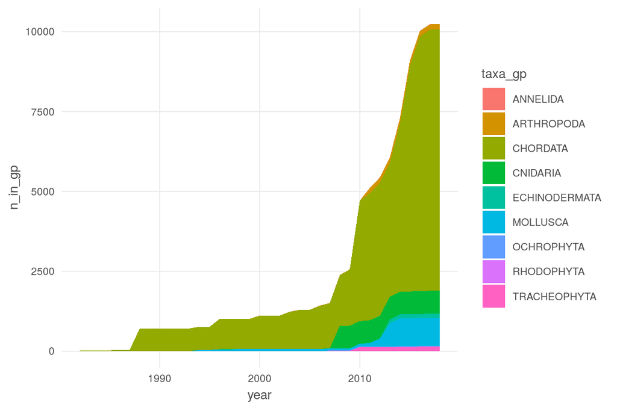

```r
# spp_timeseries_file <- file.path(dir_git, 'data', sprintf('iucn_risk_timeseries_%s.csv', api_version))
# spp_info_from_api_file <- file.path(dir_o_anx, sprintf('iucn/spp_info_from_api_%s.csv', api_version))

spp_ts <- read_csv(spp_timeseries_file, col_types = 'ddcdc')

spp_class <- read_csv(spp_info_from_api_file, col_types = 'dccccccccc')

spp_assessed_yr_class <- spp_ts %>%
  filter(!is.na(cat_ts_score)) %>%
  group_by(year, iucn_sid) %>%
  complete(year = min(year):2018) %>%
  arrange(year) %>%
  ungroup() %>%
  left_join(spp_class, by = 'iucn_sid') %>%
  select(year, iucn_sid, kingdom, phylum, class, order) %>%
  distinct()

spp_assessed <- spp_assessed_yr_class %>%
  mutate(taxa_gp = phylum) %>%
  group_by(year, taxa_gp) %>%
  summarize(n_in_gp = n()) %>%
  group_by(taxa_gp) %>%
  complete(year = 1965:2018) %>%
  mutate(n_in_gp = ifelse(is.na(n_in_gp), 0, n_in_gp)) %>%
  ungroup()

ggplot(spp_assessed, aes(x = year, y = n_in_gp, fill = taxa_gp)) +
  ggtheme_plot() +
  geom_area() +
  scale_x_continuous(limits = c(1982, 2018))
```

```r
spp_class_order <- spp_ts %>%
  filter(!is.na(cat_ts_score)) %>%
  select(-year, -cat_ts_score) %>%
  distinct() %>%
  left_join(spp_class, by = 'iucn_sid') %>%
  group_by(kingdom, phylum, class, order) %>%
  summarize(n_in_order = n()) %>%
  group_by(class) %>%
  mutate(n_in_class = sum(n_in_order)) %>%
  ungroup()
```

```r
prov_wrapup(commit_outputs = FALSE)
```

# 4 Provenance

- *Run ID: 4 (2c32bb2); run tag: “standard run”*
- *Run elapsed time: 41.52 seconds; run memory usage: 8092.7 MB*
- *System info:*
  - *System: Linux, Release: 4.4.0-112-generic. Machine: x86_64. User: ohara.*
  - *R version: R version 3.4.4 (2018-03-15), Platform: x86_64-pc-linux-gnu, Running under: Ubuntu 14.04.5 LTS.*
  - *Attached base packages: parallel, stats, graphics, grDevices, utils, datasets, methods, base*
  - *Other attached packages: bindrcpp_0.2.2, jsonlite_1.5, provRmd_0.1.1, RColorBrewer_1.1-2, forcats_0.3.0, stringr_1.3.1, dplyr_0.7.6, purrr_0.2.5, readr_1.1.1, tidyr_0.8.1, tibble_1.4.2, ggplot2_3.0.0, tidyverse_1.2.1*

[figure not shown]

| sequence | file_name | parent_chunk | file_dir | filetype | uncomm_chgs | commit_hash_short |
| --- | --- | --- | --- | --- | --- | --- |
| 0 | 1_set_up_iucn_risk.Rmd | prov_footer | ~/github/spp_risk_dists/data_setup | parent_script | True | f8c9c98 |
| 0 | 1_set_up_iucn_risk.Rmd#determine_marine_spp_from_api | determine_marine_spp_from_api | ~/github/spp_risk_dists/data_setup | parent_chunk | True | f8c9c98 |
| 0 | 1_set_up_iucn_risk.Rmd#determine_spp_habs | determine_spp_habs | ~/github/spp_risk_dists/data_setup | parent_chunk | True | f8c9c98 |
| 0 | 1_set_up_iucn_risk.Rmd#determine_spp_systems | determine_spp_systems | ~/github/spp_risk_dists/data_setup | parent_chunk | True | f8c9c98 |
| 0 | 1_set_up_iucn_risk.Rmd#generate_hab_inclusion_list | generate_hab_inclusion_list | ~/github/spp_risk_dists/data_setup | parent_chunk | True | f8c9c98 |
| 0 | 1_set_up_iucn_risk.Rmd#get_iucn_current_assessment | get_iucn_current_assessment | ~/github/spp_risk_dists/data_setup | parent_chunk | True | f8c9c98 |
| 0 | 1_set_up_iucn_risk.Rmd#get_iucn_past_assessments | get_iucn_past_assessments | ~/github/spp_risk_dists/data_setup | parent_chunk | True | f8c9c98 |
| 0 | 1_set_up_iucn_risk.Rmd#get_spp_info_from_api | get_spp_info_from_api | ~/github/spp_risk_dists/data_setup | parent_chunk | True | f8c9c98 |
| 0 | 1_set_up_iucn_risk.Rmd#prov_footer | prov_footer | ~/github/spp_risk_dists/data_setup | parent_chunk | True | f8c9c98 |
| 0 | 1_set_up_iucn_risk.Rmd#setup | setup | ~/github/spp_risk_dists/data_setup | parent_chunk | True | f8c9c98 |

[output cut: 21 more lines]